## Report: act_report

- Create a **250-word-minimum written report** called "act_report.pdf" or "act_report.html" that communicates the insights and displays the visualization(s) produced from your wrangled data. This is to be framed as an external document, like a blog post or magazine article, for example.

# WeRateDogs

## A Data-Wrangling project by Muheez Okunade

Data confirms it: people love puppos!\ WeRateDogs is a popular Twitter account that posts funny comments and rates of dogs from photos submitted by their followers. Active since November 2015, and with over 7.6 million followers by January 2019, it has grown beyond being a twitter account to launch even a store with dog-related products. WeRateDogs has even developed its own dog classification, based on the dog’s age and appearance. Puppies are “puppers”, older puppers are “puppos”, older puppers are “doggos” and hairy dogs (or almost every dog) are “floofers”. We decided to research what the most popular dog stage is, and the clear winners are “puppos”! We retrieved data from over 3,000 WeRateDogstweets, including its favorite and retweet count. After some data cleaning we could see that the puppos (or the equivalent of “Teenager” dogs) are the most retweeted and liked from all.

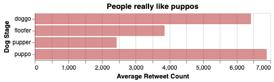

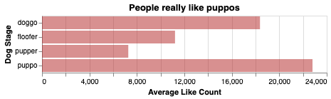

They also received in average the best ratings from the account owners. WeRateDogs considers every dog as better than 10/10, and rates them usually between 10/10 and 15/10. Under this scale, the mean rating for “puppos” is 12.

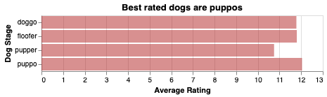

Beyond this seemingly anecdotal figures, hides a social networking success story. A twitter account is usually considered successful according to its number of followers and to how much its followers engage with the content via likes (“favorites” in twitter jargon) and retweets. 7.6 million followers are already a very good sign of the success of WeRateDogs, but its average like and retweet count are outstanding:

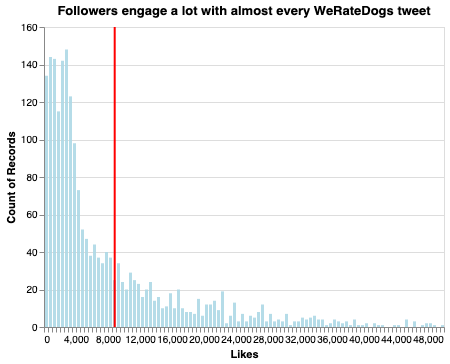

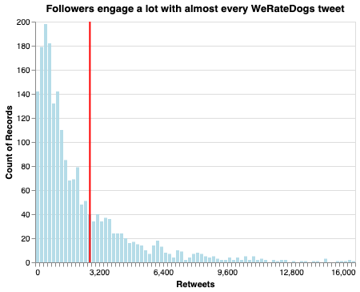